# TP MPDW Pert 5

NIda Khairunnissa

2025-09-27

# STUDI KASUS

Ingin diketahui apakah data harga BTC stasioner dalam rataan dan stasioner dalam ragam atau tidak. Jika diketahui data tersebut tidak stasioner, maka akan dilakukan penanganan yang sesuai agar data tersebut menjadi stasioner dalam rataan dan ragam.

## Library

```r
library(ggplot2)
library(tsibble)
library(tseries)
library(MASS)
library(rio)
```

## Input Data

```r
# Data BTC Price
data <- import("https://raw.githubusercontent.com/nida-kha44/MPDW/refs/heads/main/Pertemuan%201/btc_historical_price.csv")
head(data)
```

```
##         date price
## 1 2011-01-01 0.300
## 2 2011-01-02 0.300
## 3 2011-01-03 0.295
## 4 2011-01-04 0.299
## 5 2011-01-05 0.299
## 6 2011-01-06 0.298
```

```r
# Pembagian Data BTC Price
btcprice <- data[1655:2485, ]
head(btcprice)
```

```
##            date    price
## 1655 2015-07-13 290.8811
## 1656 2015-07-14 286.1856
## 1657 2015-07-15 283.8231
## 1658 2015-07-16 277.8273
## 1659 2015-07-17 278.4883
## 1660 2015-07-18 274.4938
```

```r
# Ubah jadi time series
btcprice.ts <- ts(btcprice$price, frequency = 1)
```

## Eksplorasi Data BTC Price

### Plot Time Series

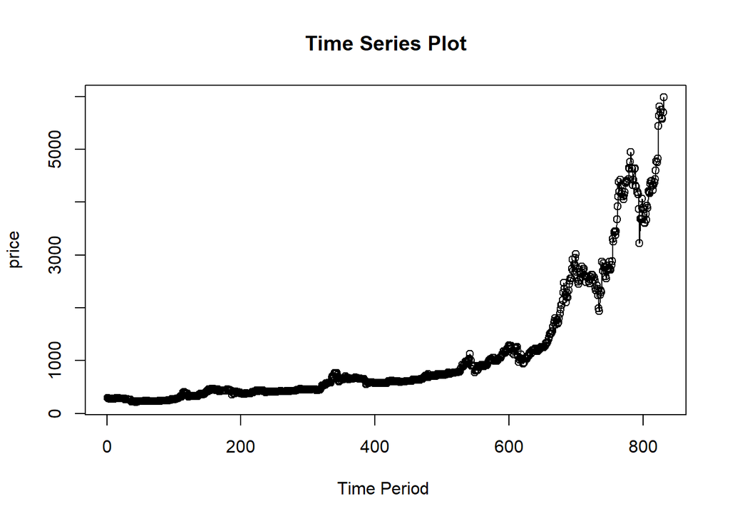

```r
ts.plot(btcprice.ts, xlab="Time Period ", ylab="price",
        main = "Time Series Plot")
points(btcprice.ts)
```

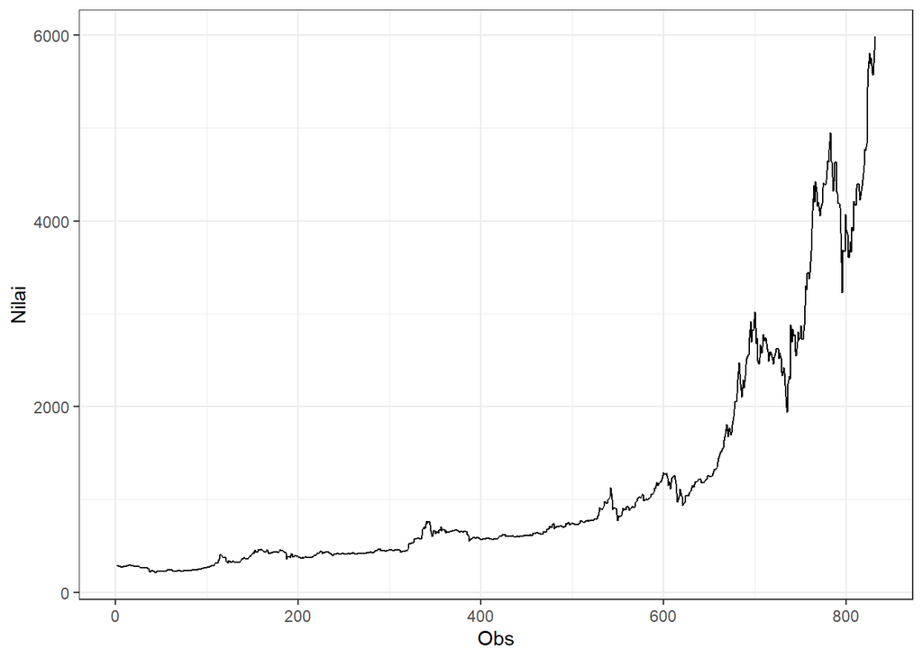

```r
plot_btcprice <- btcprice.ts |>
  as_tsibble() |>
  ggplot(aes(x = index, y = value)) +
  geom_line() +
  theme_bw() +
  xlab("Obs") +
  ylab("Nilai")

plot_btcprice
```

```r
# Hitung rata-rata
mean(btcprice.ts)
```

```
## [1] 1144.023
```

Plot deret waktu di atas menunjukkan bahwa data tidak stasioner dalam rataan, ditandai dengan adanya tren peningkatan tajam dari waktu ke waktu (harga semakin naik). Selain itu, data juga tidak stasioner dalam ragam, ditandai dengan fluktuasi (volatilitas) yang semakin besar seiring bertambahnya waktu.

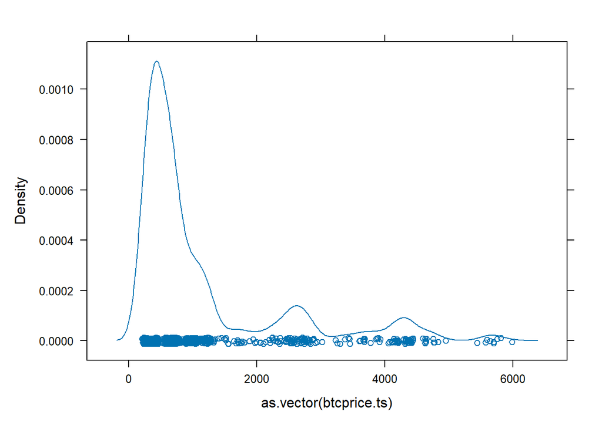

```r
# Density plot
lattice::densityplot(as.vector(btcprice.ts))
```

Density plot di atas menunjukkan bahwa data BTC Price tidak stasioner dalam rataan maupun ragam, terlihat dari distribusi yang sangat miring ke kanan dengan sebaran yang tidak merata.

### Plot ACF

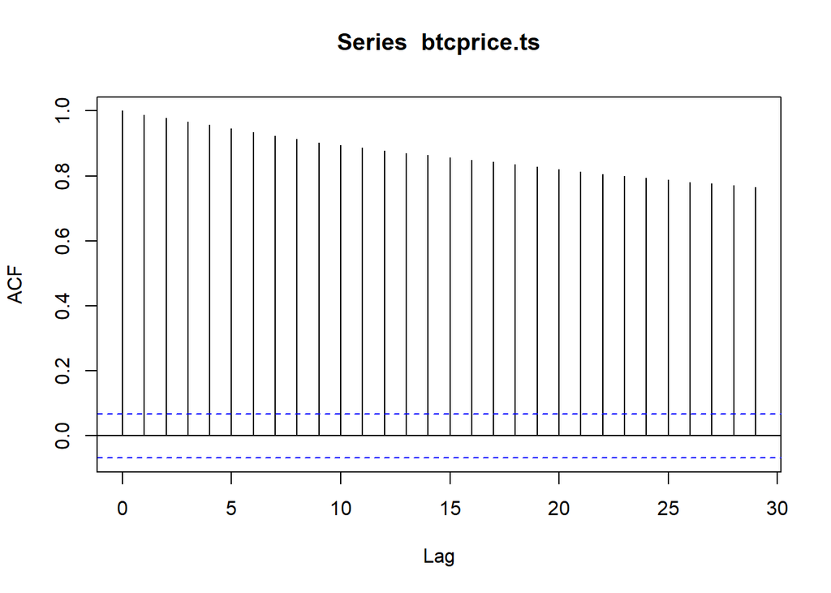

```r
acf(btcprice.ts)
```

Berdasarkan plot ACF, terlihat bahwa plot ACF pada data tersebut menurun secara perlahan (*tails off slowly*) yang menandakan data tidak stasioner dalam rataan

### Uji ADF

$H_0$ : Data tidak stasioner dalam rataan

$H_1$ : Data stasioner dalam rataan

```r
adf.test(btcprice.ts)
```

```
##
##  Augmented Dickey-Fuller Test
##
## data:  btcprice.ts
## Dickey-Fuller = 1.3165, Lag order = 9, p-value = 0.99
## alternative hypothesis: stationary
```

### Plot Box-Cox

```r
library(forecast)
```

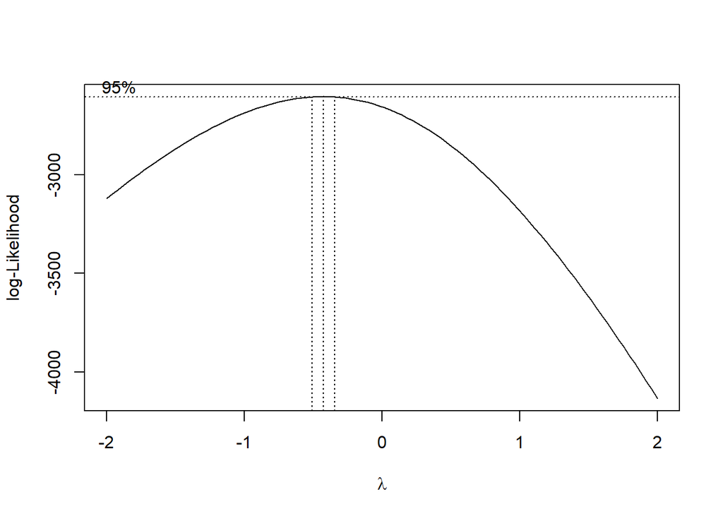

```r
# Misal btcprice.ts sudah berupa objek ts
# Cari nilai lambda terbaik
lambda <- BoxCox.lambda(btcprice.ts)

# Plot Box-Cox Transformation
boxcox(btcprice.ts ~ 1, lambda = seq(-2, 2, 0.1))
```

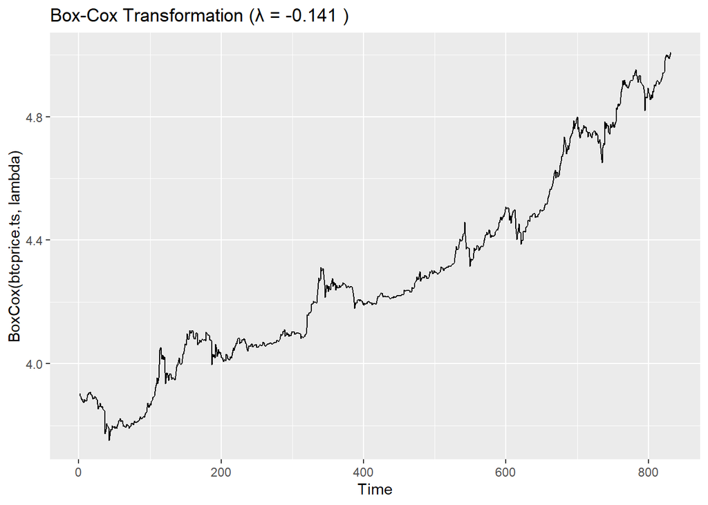

```r
# Atau lebih praktis pakai fungsi dari forecast
autoplot(BoxCox(btcprice.ts, lambda)) +
  ggtitle(paste("Box-Cox Transformation (λ =", round(lambda, 3), ")"))
```

## Penanganan Ketidak Stasioneran

### Penanganan Tidak Stasioner dalam Ragam

```r
# Transformasi log pada data btc price
btcprice.log <- log(btcprice.ts)
head(btcprice.log)
```

```
## Time Series:
## Start = 1
## End = 6
## Frequency = 1
## [1] 5.672915 5.656641 5.648351 5.627000 5.629376 5.614929
```

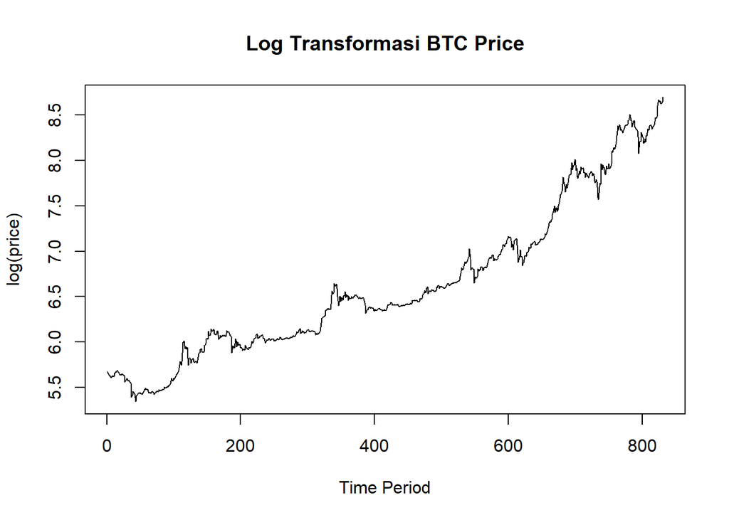

```r
# Tampilan plot time series data yang sudah ditramsformasi log
ts.plot(btcprice.log,
        main = "Log Transformasi BTC Price",
        ylab = "log(price)",
        xlab = "Time Period")
```

```r
btcprice.log
```

[output not shown]

[output cut: 93 more lines]

### Penanganan Tidak Stasioner dalam Rataan

```r
# Differencing Orde 1
btcprice.logdiff1 <- diff(btcprice.log, differences = 1)
head(btcprice.logdiff1)
```

```
## Time Series:
## Start = 2
## End = 7
## Frequency = 1
## [1] -0.016274041 -0.008289395 -0.021351459  0.002376350 -0.014447374
## [6] -0.007330795
```

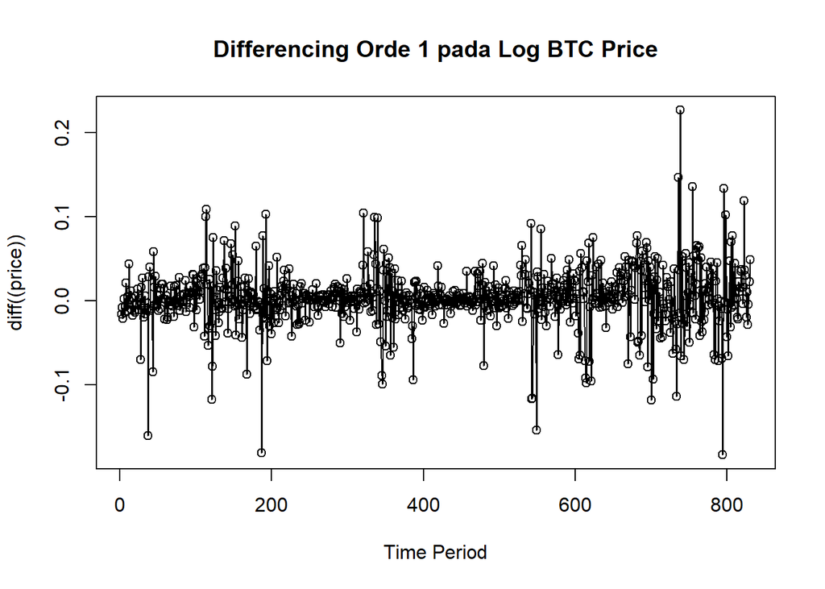

```r
# Tampilan plot time series data yang sudah di-Log dan di-Differencing
ts.plot(btcprice.logdiff1,
        main = "Differencing Orde 1 pada Log BTC Price",
        ylab = "diff((price))",
        xlab = "Time Period")
points(btcprice.logdiff1)
```

### Eksplorasi Data BTC Price yang sudah ditangani

#### Plot Time Series

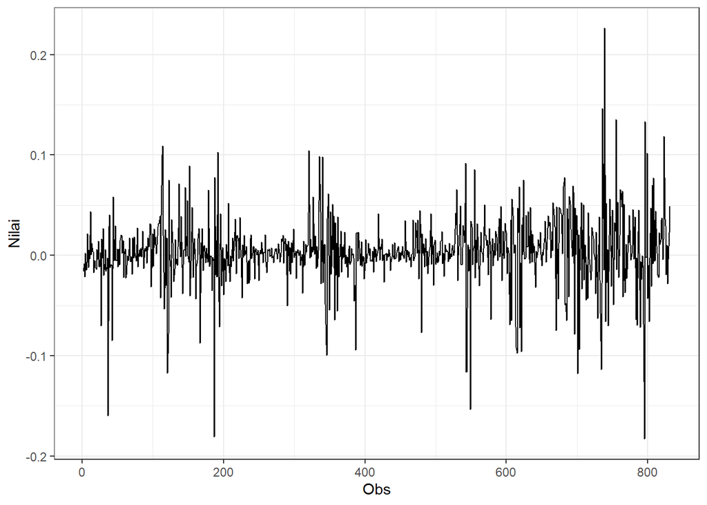

```r
plot_btcprice.logdiff1 <- btcprice.logdiff1 |>
  as_tsibble() |>
  ggplot(aes(x = index, y = value)) +
  geom_line() +
  theme_bw() +
  xlab("Obs") +
  ylab("Nilai")

plot_btcprice.logdiff1
```

```r
# Hitung rata-rata
mean(btcprice.logdiff1)
```

```
## [1] 0.003643306
```

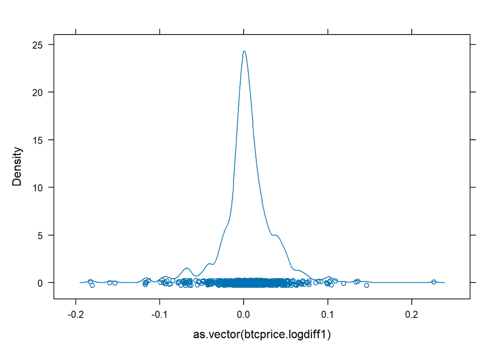

```r
# Density plot
lattice::densityplot(as.vector(btcprice.logdiff1))
```

Density plot di atas mengindikasikan bahwa data BTC Price stasioner dalam rataan maupun ragam, terlihat dari distribusi yang menyebar normal dengan sebaran yang cukup merata.

#### Plot ACF

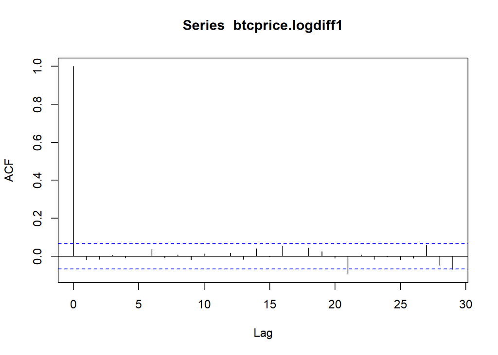

```r
acf(btcprice.logdiff1)
```

#### Uji ADF

$H_0$ : Data tidak stasioner dalam rataan

$H_1$ : Data stasioner dalam rataan

```r
adf.test(btcprice.logdiff1)
```

```
##
##  Augmented Dickey-Fuller Test
##
## data:  btcprice.logdiff1
## Dickey-Fuller = -9.0823, Lag order = 9, p-value = 0.01
## alternative hypothesis: stationary
```

Berdasarkan uji ADF tersebut, didapat *p-value* sebesar 0.01 yang lebih kecil dari taraf nyata 5% dan menandakan bahwa data stasioner dalam rataan. Hal ini sesuai dengan hasil eksplorasi menggunakan plot time series dan plot ACF

## Pembuktian Kestasioneran pada Data dengan Partisi Data

### Pembagian Data

```r
# Cek panjang data
n <- length(btcprice.logdiff1)
n
```

```
## [1] 830
```

```r
# Tentukan titik pembagi (misal 60% - 40%)
split_point <- floor(0.4 * n)
```

### Bagian 1

```r
btc_part1 <- btcprice.logdiff1[1:split_point] |> ts()
length(btc_part1)
```

```
## [1] 332
```

```r
mean(btc_part1); var(btc_part1)
```

```
## [1] 0.002060184
```

```
## [1] 0.0008472046
```

#### Eksplorasi Data

##### Plot Time Series

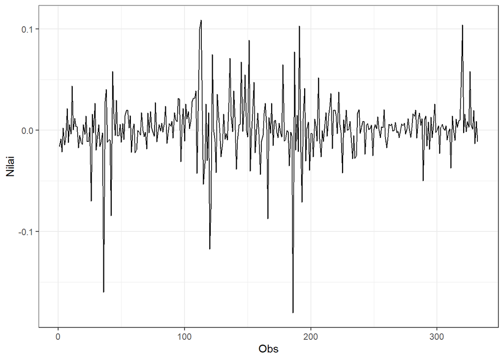

```r
btc_part1 |> as_tsibble() |>
  ggplot(aes(x = index, y = value)) +
  geom_line() + theme_bw() +
  xlab("Obs") + ylab("Nilai")
```

##### Plot ACF

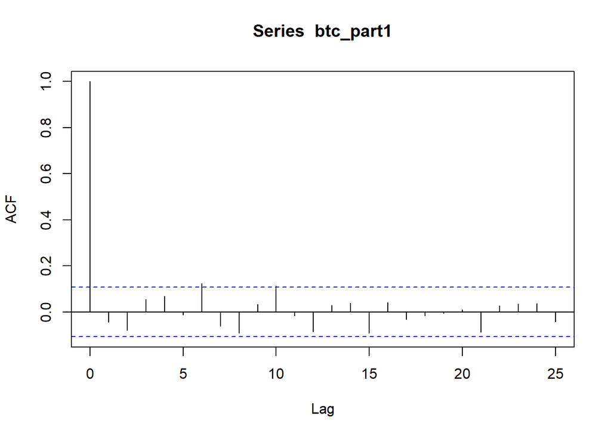

```r
acf(btc_part1)
```

Berdasarkan plot ACF, terlihat bahwa data cenderung stasioner dalam rataan ditandai dengan plot ACF yang *cut off* pada lag pertama.

#### Uji ADF

```r
adf.test(btc_part1)
```

```
##
##  Augmented Dickey-Fuller Test
##
## data:  btc_part1
## Dickey-Fuller = -6.1954, Lag order = 6, p-value = 0.01
## alternative hypothesis: stationary
```

$H_0$ : Data tidak stasioner dalam rataan

$H_1$ : Data stasioner dalam rataan

Berdasarkan uji ADF tersebut, didapat *p-value* sebesar 0.01 yang kurang dari taraf nyata 5% dan menandakan bahwa data stasioner dalam rataan. Hal ini sesuai dengan hasil eksplorasi menggunakan plot time series dan plot ACF

##### Plot Boxcox

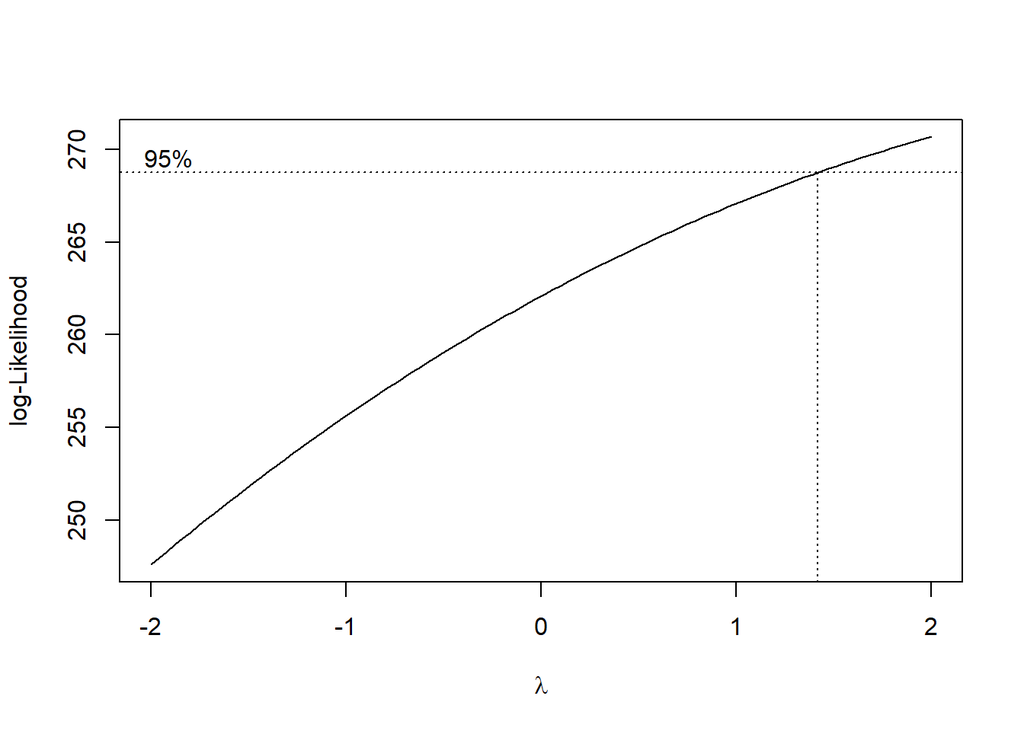

```r
# Buat indeks berdasarkan panjang data
index <- seq(1, length(btc_part1))

# Uji BoxCox
bc <- boxcox(btc_part1 + abs(min(btc_part1)) + 1 ~ index,
             lambda = seq(-2, 2, by = 0.1))
```

```r
# Ambil lambda terbaik
lambda <- bc$x[which.max(bc$y)]
lambda
```

```
## [1] 2
```

```r
# Selang kepercayaan lambda
bc$x[bc$y > max(bc$y) - 1/2 * qchisq(.95, 1)]
```

```
##  [1] 1.434343 1.474747 1.515152 1.555556 1.595960 1.636364 1.676768 1.717172
##  [9] 1.757576 1.797980 1.838384 1.878788 1.919192 1.959596 2.000000
```

### Bagian 2

```r
btc_part2 <- btcprice.logdiff1[(split_point+1):n] |> ts()
length(btc_part2)
```

```
## [1] 498
```

```r
mean(btc_part1); var(btc_part2)
```

```
## [1] 0.002060184
```

```
## [1] 0.001440982
```

#### Eksplorasi Data

##### Plot Time Series

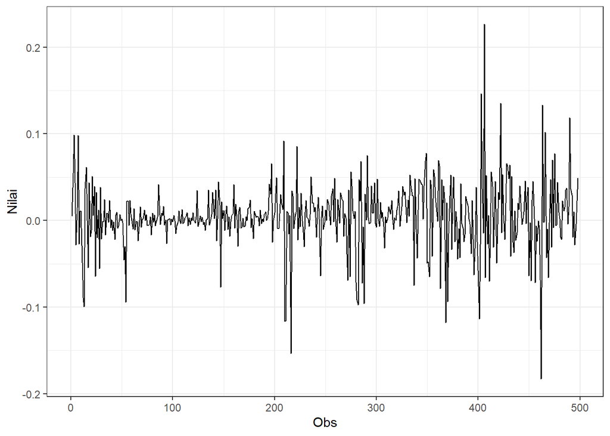

```r
btc_part2 |> as_tsibble() |>
  ggplot(aes(x = index, y = value)) +
  geom_line() + theme_bw() +
  xlab("Obs") + ylab("Nilai")
```

Berdasarkan plot time series tersebut, terlihat bahwa data cenderung stasioner dalam rataan, ditandain dengan tidak adanya trend dan musiman pada data, serta stasioner dalam ragam, ditandai dengan lebar pita yang cenderung sama pada plot tersebut

##### Plot ACF

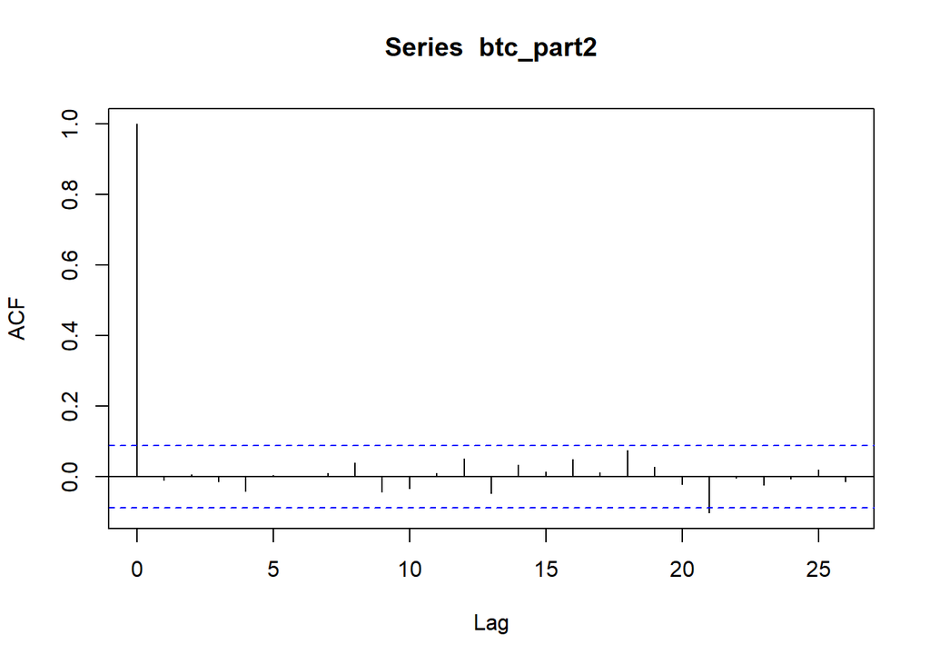

```r
acf(btc_part2)
```

Berdasarkan plot ACF, terlihat bahwa data cenderung stasioner dalam rataan ditandai dengan plot ACF yang *cut off* pada lag pertama.

#### Uji ADF

```r
adf.test(btc_part2)
```

```
##
##  Augmented Dickey-Fuller Test
##
## data:  btc_part2
## Dickey-Fuller = -8.0966, Lag order = 7, p-value = 0.01
## alternative hypothesis: stationary
```

$H_0$ : Data tidak stasioner dalam rataan

$H_1$ : Data stasioner dalam rataan

Berdasarkan uji ADF tersebut, didapat *p-value* sebesar 0.01 yang kurang dari taraf nyata 5% dan menandakan bahwa data stasioner dalam rataan. Hal ini sesuai dengan hasil eksplorasi menggunakan plot time series dan plot ACF

##### Plot Boxcox

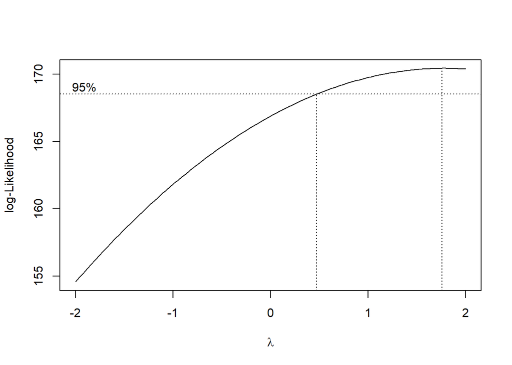

```r
# Buat indeks berdasarkan panjang data
index <- seq(1, length(btc_part2))

# Uji BoxCox
bc <- boxcox(btc_part2 + abs(min(btc_part2)) + 1 ~ index,
             lambda = seq(-2, 2, by = 0.1))
```

```r
# Ambil lambda terbaik
lambda <- bc$x[which.max(bc$y)]
lambda
```

```
## [1] 1.757576
```

```r
# Selang kepercayaan lambda
bc$x[bc$y > max(bc$y) - 1/2 * qchisq(.95, 1)]
```

```
##  [1] 0.5050505 0.5454545 0.5858586 0.6262626 0.6666667 0.7070707 0.7474747
##  [8] 0.7878788 0.8282828 0.8686869 0.9090909 0.9494949 0.9898990 1.0303030
## [15] 1.0707071 1.1111111 1.1515152 1.1919192 1.2323232 1.2727273 1.3131313
## [22] 1.3535354 1.3939394 1.4343434 1.4747475 1.5151515 1.5555556 1.5959596
## [29] 1.6363636 1.6767677 1.7171717 1.7575758 1.7979798 1.8383838 1.8787879
## [36] 1.9191919 1.9595960 2.0000000
```

Hasil Box-Cox menunjukkan bahwa nilai λ = 1 masih termasuk dalam interval 95%. Artinya, data btc_part2 stasioner dalam ragam.